# Adaptive PDAC

Sara Söderqvist

2023-05-04

## Adaptive PDAC - Background

This is a study of compartment-dependent heterogeneity in pancreatic cancer. In conclusion, we can reveal that intratumor heterogeneity in many cases is related to the invasion front properties; Tumor invading stroma or tumor invading lobes - the acinar invasion.

31 cases had 6 immunohistochemistry markers quantified in QuPath, 4 related to the basal like subtype (CK/KRT17, CK/KRT5, CA125 and HMGA2) and 2 related to the classical subtype (Muc5 and CDX2, which also relates to intestinal expression). Not all stains were available for all cases, which is stated in the supplementary material.

For each case, up to 9 regions of interest (ROIs) for “tumor in septa” (=stroma) and 9 ROIs representing “tumor in acinar (=lobular) invasion”. The ROIs are overlapping across the different stains. All quantifications extracted are only including tumor cells. Data cleanup include removal of ev. annotations in the images that helped correct ROI setting.

```r
library(tidyr)
library(dplyr)
library(rstatix)
library(reactable)
library(ggthemes)
library(ggpubr)
library(data.table)
library(reshape2)
```

```r
library(corrplot)
library(patchwork)
library(ggplot2)
library(ComplexHeatmap)
library(viridis)
library(RColorBrewer)
library(ggVennDiagram)
library(dichromat)
library(survminer)
library(BioVenn)
library(Hmisc)
library(stringr)
library(forcats)
library(ggridges)
library(hrbrthemes)
```

### The data and groupings:

## Tables of Wilcoxon-tests with median and mean, separated on each stain

```r
reactable(stat.test.CK17_m, striped = T, bordered = T, defaultPageSize = 16, showPageInfo = FALSE, showPageSizeOptions = TRUE, filterable = T)
```

| PKR | .y. | group1 | group2 | n1 | n2 | statistic | p | p.adj | p.adj.signif | Median_CK17_Stroma | Median_CK17_Lobule | Mean_CK17_Stroma | Mean_CK17_Lobule |
| --- | --- | --- | --- | --- | --- | --- | --- | --- | --- | --- | --- | --- | --- |
| 1 | Tumor..Positive.. | Lobule | Stroma | 5 | 9 | 15 | 0.364 | 0.403 | ns | 97.27 | 94.78 | 95.0844444444444 | 93.554 |
| 11 | Tumor..Positive.. | Lobule | Stroma | 9 | 9 | 8 | 0.00276 | 0.00777818181818182 | ** | 98.15 | 93.66 | 97.5411111111111 | 82.5645555555556 |
| 12 | Tumor..Positive.. | Lobule | Stroma | 9 | 9 | 43 | 0.863 | 0.891766666666667 | ns | 5.643 | 6.914 | 8.30266666666667 | 9.20385555555556 |
| 13 | Tumor..Positive.. | Lobule | Stroma | 9 | 9 | 2 | 0.000165 | 0.001705 | ** | 70.2 | 22.56 | 74.4111111111111 | 28.6424444444444 |
| 14 | Tumor..Positive.. | Lobule | Stroma | 9 | 9 | 15 | 0.0244 | 0.0444941176470588 | * | 38.66 | 24.57 | 36.9277777777778 | 22.7647777777778 |
| 15 | Tumor..Positive.. | Lobule | Stroma | 7 | 9 | 30 | 0.918 | 0.918 | ns | 3.922 | 4.101 | 6.99188888888889 | 7.22185714285714 |
| 16 | Tumor..Positive.. | Lobule | Stroma | 9 | 9 | 2 | 0.000787 | 0.00406616666666667 | ** | 42.72 | 0.6061 | 49.546 | 2.45064444444444 |
| 17 | Tumor..Positive.. | Lobule | Stroma | 9 | 9 | 50 | 0.436 | 0.466068965517241 | ns | 18.32 | 27.62 | 24.008 | 27.5488888888889 |
| 18 | Tumor..Positive.. | Lobule | Stroma | 9 | 9 | 6 | 0.00267 | 0.00777818181818182 | ** | 19.15 | 3.736 | 18.0956666666667 | 4.19527777777778 |
| 2 | Tumor..Positive.. | Lobule | Stroma | 9 | 9 | 0 | 4.11e-05 | 0.00063705 | *** | 82.74 | 22.68 | 83.0344444444444 | 19.6107777777778 |

[output cut: 21 more lines]

```r
reactable(stat.test.Muc5_m, striped = T, bordered = T, defaultPageSize = 16, showPageInfo = FALSE, showPageSizeOptions = TRUE, filterable = T)
```

| PKR | .y. | group1 | group2 | n1 | n2 | statistic | p | p.adj | p.adj.signif | Median_Muc5_Stroma | Median_Muc5_Lobule | Mean_Muc5_Stroma | Mean_Muc5_Lobule |
| --- | --- | --- | --- | --- | --- | --- | --- | --- | --- | --- | --- | --- | --- |
| 1 | Tumor..Positive.. | Lobule | Stroma | 5 | 9 | 27 | 0.606 | 0.78275 | ns | 14.92 | 15.83 | 17.943 | 19.23 |
| 11 | Tumor..Positive.. | Lobule | Stroma | 9 | 9 | 66 | 0.0244 | 0.0540285714285714 | ns | 6.667 | 21.33 | 8.92121111111111 | 30.1903333333333 |
| 12 | Tumor..Positive.. | Lobule | Stroma | 9 | 9 | 52 | 0.331 | 0.488619047619048 | ns | 6.091 | 39.66 | 20.6047777777778 | 30.4153333333333 |
| 13 | Tumor..Positive.. | Lobule | Stroma | 9 | 9 | 78 | 0.000288 | 0.002232 | ** | 30.75 | 63.4 | 22.4693888888889 | 65.5655555555556 |
| 14 | Tumor..Positive.. | Lobule | Stroma | 9 | 9 | 38 | 0.863 | 0.956571428571429 | ns | 65.06 | 68.04 | 69.4033333333333 | 66.6177777777778 |
| 15 | Tumor..Positive.. | Lobule | Stroma | 7 | 9 | 22 | 0.351 | 0.494590909090909 | ns | 36.86 | 30.05 | 53.6844444444444 | 44.1242857142857 |
| 16 | Tumor..Positive.. | Lobule | Stroma | 9 | 9 | 71 | 0.00564 | 0.021855 | * | 21.82 | 44.26 | 18.1498888888889 | 47.6311111111111 |
| 17 | Tumor..Positive.. | Lobule | Stroma | 9 | 9 | 42 | 0.931 | 0.9889 | ns | 46.15 | 45.77 | 50.2977777777778 | 48.5577777777778 |
| 18 | Tumor..Positive.. | Lobule | Stroma | 9 | 9 | 59 | 0.113 | 0.196333333333333 | ns | 82.26 | 94.76 | 83.5011111111111 | 90.6988888888889 |
| 2 | Tumor..Positive.. | Lobule | Stroma | 9 | 9 | 81 | 4.11e-05 | 0.0012741 | ** | 11.42 | 82.06 | 12.0007777777778 | 71.1322222222222 |

[output cut: 21 more lines]

```r
reactable(stat.test.CA125_m, striped = T, bordered = T, defaultPageSize = 16, showPageInfo = FALSE, showPageSizeOptions = TRUE, filterable = T)
```

| PKR | .y. | group1 | group2 | n1 | n2 | statistic | p | p.adj | p.adj.signif | Median_CA125_Stroma | Median_CA125_Lobule | Mean_CA125_Stroma | Mean_CA125_Lobule |
| --- | --- | --- | --- | --- | --- | --- | --- | --- | --- | --- | --- | --- | --- |
| 1 | Tumor..Positive.. | Lobule | Stroma | 5 | 9 | 4 | 0.012 | 0.044 | * | 56.59 | 37.58 | 58.1666666666667 | 39.996 |
| 11 | Tumor..Positive.. | Lobule | Stroma | 9 | 9 | 31 | 0.396 | 0.672375 | ns | 0.216 | 0 | 1.548 | 0.558022222222222 |
| 14 | Tumor..Positive.. | Lobule | Stroma | 9 | 9 | 2 | 0.000773 | 0.00566866666666667 | ** | 7.783 | 0.2558 | 12.7616666666667 | 0.595677777777778 |
| 15 | Tumor..Positive.. | Lobule | Stroma | 7 | 9 | 21 | 0.299 | 0.6578 | ns | 5.143 | 3.436 | 6.97894444444444 | 4.06272857142857 |
| 16 | Tumor..Positive.. | Lobule | Stroma | 9 | 9 | 9 | 0.00345 | 0.018975 | * | 3.908 | 0 | 25.1886222222222 | 2.24333333333333 |
| 2 | Tumor..Positive.. | Lobule | Stroma | 9 | 9 | 0 | 4.11e-05 | 0.0009042 | *** | 76.52 | 24.93 | 77.6455555555555 | 19.8483333333333 |
| 24 | Tumor..Positive.. | Lobule | Stroma | 6 | 9 | 6 | 0.012 | 0.044 | * | 58.12 | 31.42 | 58.5333333333333 | 33.5933333333333 |
| 29 | Tumor..Positive.. | Lobule | Stroma | 9 | 9 | 32 | 0.479 | 0.672375 | ns | 19.83 | 8.333 | 15.0628888888889 | 10.3764444444444 |
| 46 | Tumor..Positive.. | Lobule | Stroma | 7 | 9 | 26.5 | 0.631 | 0.730631578947368 | ns | 1.31 | 0.4938 | 2.73177777777778 | 0.981785714285714 |
| 47 | Tumor..Positive.. | Lobule | Stroma | 2 | 4 | 3 | 0.8 | 0.838095238095238 | ns | 0.86495 | 0.6665 | 1.22465 | 0.6665 |

[output cut: 20 more lines]

```r
reactable(stat.test.CK5_m, striped = T, bordered = T, defaultPageSize = 16, showPageInfo = FALSE, showPageSizeOptions = TRUE, filterable = T)
```

| PKR | .y. | group1 | group2 | n1 | n2 | statistic | p | p.adj | p.adj.signif | Median_CK5_Stroma | Median_CK5_Lobule | Mean_CK5_Stroma | Mean_CK5_Lobule |
| --- | --- | --- | --- | --- | --- | --- | --- | --- | --- | --- | --- | --- | --- |
| 11 | Tumor..Positive.. | Lobule | Stroma | 9 | 9 | 46 | 0.497 | 0.573461538461538 | ns | 0 | 0 | 0.133444444444444 | 1.34411111111111 |
| 14 | Tumor..Positive.. | Lobule | Stroma | 9 | 9 | 49 | 0.438 | 0.5475 | ns | 0 | 0.3145 | 0.468844444444444 | 0.479733333333333 |
| 16 | Tumor..Positive.. | Lobule | Stroma | 9 | 9 | 15 | 0.027 | 0.081 | ns | 24.65 | 0.8596 | 43.7937888888889 | 4.53013333333333 |
| 18 | Tumor..Positive.. | Lobule | Stroma | 9 | 9 | 32 | 0.332 | 0.452727272727273 | ns | 0 | 0 | 0.392011111111111 | 0.0759333333333333 |
| 2 | Tumor..Positive.. | Lobule | Stroma | 9 | 9 | 9 | 0.00593 | 0.0439 | * | 9.873 | 0.3289 | 17.9690888888889 | 2.19087777777778 |
| 24 | Tumor..Positive.. | Lobule | Stroma | 6 | 9 | 7 | 0.0176 | 0.066 | ns | 7.311 | 1.2085 | 10.1377888888889 | 1.32865 |
| 30 | Tumor..Positive.. | Lobule | Stroma | 9 | 9 | 56 | 0.181 | 0.301666666666667 | ns | 0.177 | 2.188 | 1.84021111111111 | 9.97285555555555 |
| 4 | Tumor..Positive.. | Lobule | Stroma | 9 | 9 | 37 | 0.782 | 0.782 | ns | 0.6623 | 0.4264 | 1.28081111111111 | 1.1562 |
| 47 | Tumor..Positive.. | Lobule | Stroma | 2 | 4 | 0 | 0.133 | 0.249375 | ns | 13.5075 | 1.5875 | 13.482 | 1.5875 |
| 51 | Tumor..Positive.. | Lobule | Stroma | 6 | 9 | 6 | 0.00878 | 0.0439 | * | 0.8889 | 0 | 3.12887777777778 | 0 |

[output cut: 8 more lines]

```r
reactable(stat.test.HMGA2_m, striped = T, bordered = T, defaultPageSize = 16, showPageInfo = FALSE, showPageSizeOptions = TRUE, filterable = T)
```

| PKR | .y. | group1 | group2 | n1 | n2 | statistic | p | p.adj | p.adj.signif | Median_HMGA2_Stroma | Median_HMGA2_Lobule | Mean_HMGA2_Stroma | Mean_HMGA2_Lobule |
| --- | --- | --- | --- | --- | --- | --- | --- | --- | --- | --- | --- | --- | --- |
| 11 | Tumor..Positive.. | Lobule | Stroma | 9 | 9 | 32.5 | 0.508 | 0.5588 | ns | 13.96 | 9.898 | 15.1773444444444 | 11.3480666666667 |
| 12 | Tumor..Positive.. | Lobule | Stroma | 9 | 9 | 0 | 4.11e-05 | 0.00022605 | *** | 51.77 | 5.956 | 40.8855555555556 | 5.91025555555556 |
| 14 | Tumor..Positive.. | Lobule | Stroma | 9 | 9 | 11 | 0.0103 | 0.028325 | * | 6.958 | 0.6154 | 8.10223333333333 | 1.77476666666667 |
| 16 | Tumor..Positive.. | Lobule | Stroma | 9 | 9 | 22 | 0.111 | 0.205333333333333 | ns | 3.067 | 0.9464 | 12.1829888888889 | 0.744144444444444 |
| 18 | Tumor..Positive.. | Lobule | Stroma | 9 | 9 | 24 | 0.157 | 0.246714285714286 | ns | 1.179 | 0.2667 | 6.96864444444444 | 5.74403333333333 |
| 2 | Tumor..Positive.. | Lobule | Stroma | 9 | 9 | 0 | 4.11e-05 | 0.00022605 | *** | 59.47 | 14.79 | 60.4288888888889 | 15.3078888888889 |
| 30 | Tumor..Positive.. | Lobule | Stroma | 9 | 9 | 9 | 0.00399 | 0.01463 | * | 27.67 | 3.797 | 28.2011111111111 | 14.6927777777778 |
| 4 | Tumor..Positive.. | Lobule | Stroma | 9 | 9 | 33.5 | 0.564 | 0.564 | ns | 2.206 | 0.597 | 3.41655555555556 | 1.16462222222222 |
| 63 | Tumor..Positive.. | Lobule | Stroma | 5 | 9 | 10 | 0.112 | 0.205333333333333 | ns | 87.23 | 78.78 | 86.34 | 80.852 |
| 65 | Tumor..Positive.. | Lobule | Stroma | 6 | 9 | 16 | 0.216 | 0.297 | ns | 14.01 | 9.887 | 17.5463555555556 | 10.264 |

[output cut: 11 more lines]

```r
reactable(stat.test.CDX2_m, striped = T, bordered = T, defaultPageSize = 16, showPageInfo = FALSE, showPageSizeOptions = TRUE, filterable = T)
```

| PKR | .y. | group1 | group2 | n1 | n2 | statistic | p | p.adj | p.adj.signif | Median_CDX2_Stroma | Median_CDX2_Lobule | Mean_CDX2_Stroma | Mean_CDX2_Lobule |
| --- | --- | --- | --- | --- | --- | --- | --- | --- | --- | --- | --- | --- | --- |
| 1 | Tumor..Positive.. | Lobule | Stroma | 5 | 9 | 29.5 | 0.386 | 0.4246 | ns | 0.554 | 2.649 | 0.925811111111111 | 2.86712 |
| 12 | Tumor..Positive.. | Lobule | Stroma | 9 | 9 | 54 | 0.251 | 0.320222222222222 | ns | 3.12 | 27.78 | 20.6200666666667 | 29.0218444444444 |
| 13 | Tumor..Positive.. | Lobule | Stroma | 9 | 9 | 56 | 0.19 | 0.278666666666667 | ns | 4.636 | 8.529 | 4.87365555555556 | 19.1122222222222 |
| 14 | Tumor..Positive.. | Lobule | Stroma | 9 | 9 | 51 | 0.376 | 0.4246 | ns | 0.4878 | 0.9375 | 1.44246666666667 | 2.03682222222222 |
| 15 | Tumor..Positive.. | Lobule | Stroma | 7 | 9 | 51 | 0.0418 | 0.11495 | ns | 2.857 | 6.885 | 4.55777777777778 | 9.11 |
| 16 | Tumor..Positive.. | Lobule | Stroma | 9 | 9 | 79 | 0.000547 | 0.0030085 | ** | 0 | 4.29 | 0.142755555555556 | 6.08638888888889 |
| 17 | Tumor..Positive.. | Lobule | Stroma | 9 | 9 | 53 | 0.258 | 0.320222222222222 | ns | 0 | 0.3257 | 0.265177777777778 | 0.585777777777778 |
| 18 | Tumor..Positive.. | Lobule | Stroma | 9 | 9 | 59 | 0.113 | 0.207166666666667 | ns | 1.597 | 7.788 | 4.12434444444444 | 8.88672222222222 |
| 2 | Tumor..Positive.. | Lobule | Stroma | 9 | 9 | 81 | 0.000401 | 0.00294066666666667 | ** | 0.3175 | 9.434 | 0.241211111111111 | 9.69011111111111 |
| 24 | Tumor..Positive.. | Lobule | Stroma | 6 | 9 | 37 | 0.262 | 0.320222222222222 | ns | 0.9456 | 3.2215 | 3.52298888888889 | 5.6199 |

[output cut: 18 more lines]

```r
reactable(all_combined, striped = T, bordered = T, defaultPageSize = 16, showPageInfo = FALSE, showPageSizeOptions = TRUE, filterable = T)
```

|  | PKR | Stain | Class | Num.Detections | Tumor..Positive.. | Num.Tumor..Negative | Num.Tumor..Positive | Group | Group_Case_Stain | Group_Stain_Class | Group_Case_Class | Tissue_compartment |
| --- | --- | --- | --- | --- | --- | --- | --- | --- | --- | --- | --- | --- |
| 19 | 46 | CK17 | Lob 2 | 373 | 77.48 | 84 | 289 | PKR-46 CK17 Lob 2 | PKR-46 CK17 | CK17 Lob 2 | PKR- 46 Lob 2 | Lobule |
| 20 | 46 | CK17 | Lob 3 | 343 | 92.42 | 26 | 317 | PKR-46 CK17 Lob 3 | PKR-46 CK17 | CK17 Lob 3 | PKR- 46 Lob 3 | Lobule |
| 21 | 46 | CK17 | Lob 4 | 309 | 95.79 | 13 | 296 | PKR-46 CK17 Lob 4 | PKR-46 CK17 | CK17 Lob 4 | PKR- 46 Lob 4 | Lobule |
| 22 | 46 | CK17 | Lob 5 | 323 | 95.67 | 14 | 309 | PKR-46 CK17 Lob 5 | PKR-46 CK17 | CK17 Lob 5 | PKR- 46 Lob 5 | Lobule |
| 23 | 46 | CK17 | Lob 6 | 345 | 81.16 | 65 | 280 | PKR-46 CK17 Lob 6 | PKR-46 CK17 | CK17 Lob 6 | PKR- 46 Lob 6 | Lobule |
| 24 | 46 | CK17 | Lob 1 | 319 | 89.97 | 32 | 287 | PKR-46 CK17 Lob 1 | PKR-46 CK17 | CK17 Lob 1 | PKR- 46 Lob 1 | Lobule |
| 25 | 46 | CK17 | Septa 1 | 330 | 95.76 | 14 | 316 | PKR-46 CK17 Septa 1 | PKR-46 CK17 | CK17 Septa 1 | PKR- 46 Septa 1 | Stroma |
| 26 | 46 | CK17 | Septa 2 | 326 | 99.08 | 3 | 323 | PKR-46 CK17 Septa 2 | PKR-46 CK17 | CK17 Septa 2 | PKR- 46 Septa 2 | Stroma |
| 27 | 46 | CK17 | Septa 3 | 305 | 98.69 | 4 | 301 | PKR-46 CK17 Septa 3 | PKR-46 CK17 | CK17 Septa 3 | PKR- 46 Septa 3 | Stroma |
| 28 | 46 | CK17 | Septa 4 | 356 | 99.16 | 3 | 353 | PKR-46 CK17 Septa 4 | PKR-46 CK17 | CK17 Septa 4 | PKR- 46 Septa 4 | Stroma |

[output cut: 2498 more lines]

## Boxplots

Separate for each stain, faceted on each case.  
Each dot = 1 ROI.

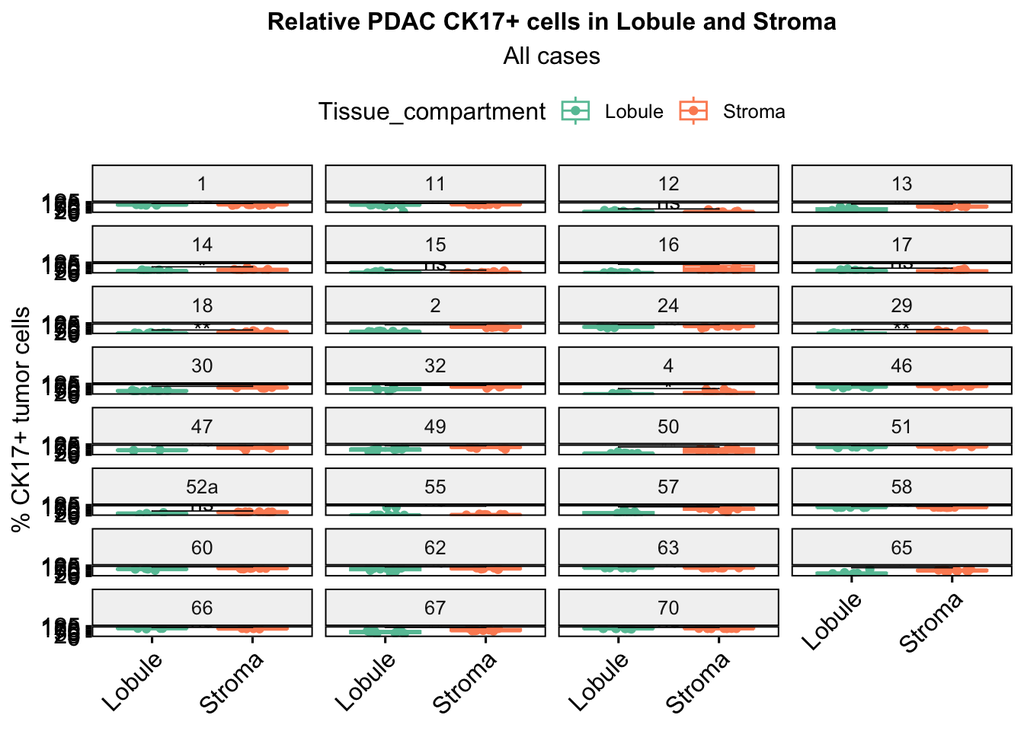

```r
boxes_ck17 <- ggboxplot(all_CK17, x = "Tissue_compartment", y = "Tumor..Positive..",
                        color = "Tissue_compartment", palette = "Set2",
                        add = "jitter",
                        facet.by = "PKR", ncol = 4, short.panel.labs = TRUE) +
  labs(title = "Relative PDAC CK17+ cells in Lobule and Stroma", subtitle = "All cases") +
  theme(plot.title = element_text(hjust = 0.5, size = 12, face = "bold"), plot.subtitle =element_text(hjust = 0.5, size = 12))+
  xlab(NULL) + ylab("% CK17+ tumor cells")  +
  ylim(-1, 120) +
  theme(plot.margin = margin(0.2, 0.2, 0.2, 0.2, "cm"))

stat.test_CK17_1 <- stat.test_CK17 %>% add_xy_position(x = "Tissue_compartment")
Suppl_Fig_4b <- boxes_ck17 +
  stat_pvalue_manual(label = "p.adj.signif",
                                stat.test_CK17_1, tip.length = 0) +
  theme(axis.text.x = element_text(angle = 45, hjust = 1))

Suppl_Fig_4b
```

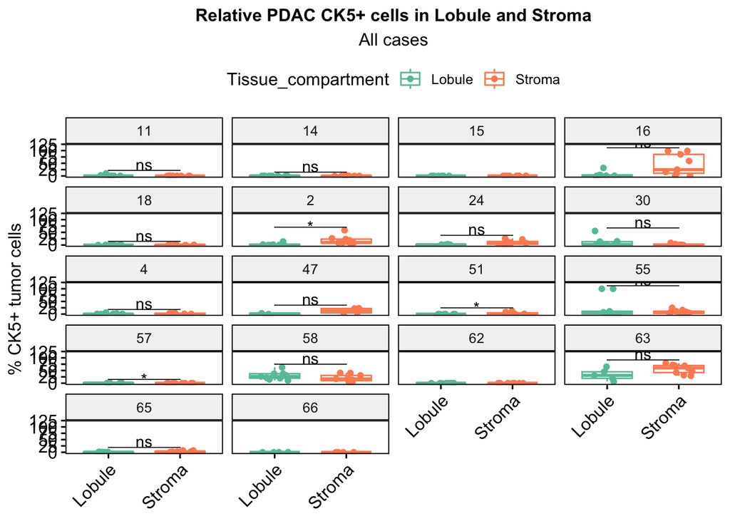

```r
boxes_ck5 <- ggboxplot(all_CK5, x = "Tissue_compartment", y = "Tumor..Positive..",
                        color = "Tissue_compartment", palette = "Set2",
                        add = "jitter",
                        facet.by = "PKR", ncol = 4, short.panel.labs = TRUE) +
  labs(title = "Relative PDAC CK5+ cells in Lobule and Stroma", subtitle = "All cases") +
  xlab(NULL) + ylab("% CK5+ tumor cells") +
  theme(plot.title = element_text(hjust = 0.5, size = 12, face = "bold"), plot.subtitle =element_text(hjust = 0.5, size = 12)) +
  theme(axis.text=element_text(size=12),
        axis.title=element_text(size=12)) +
  ylim(-1, 120) +
  theme(plot.margin = margin(0.2, 0.2, 0.2, 0.2, "cm"))

stat.test_CK5_1 <- stat.test_CK5 %>% add_xy_position(x = "Tissue_compartment")
Suppl_5b <- boxes_ck5 +
  stat_pvalue_manual(label = "p.adj.signif",
                                stat.test_CK5_1, tip.length = 0) +
  theme(axis.text.x = element_text(angle = 45, hjust = 1))

Suppl_5b
```

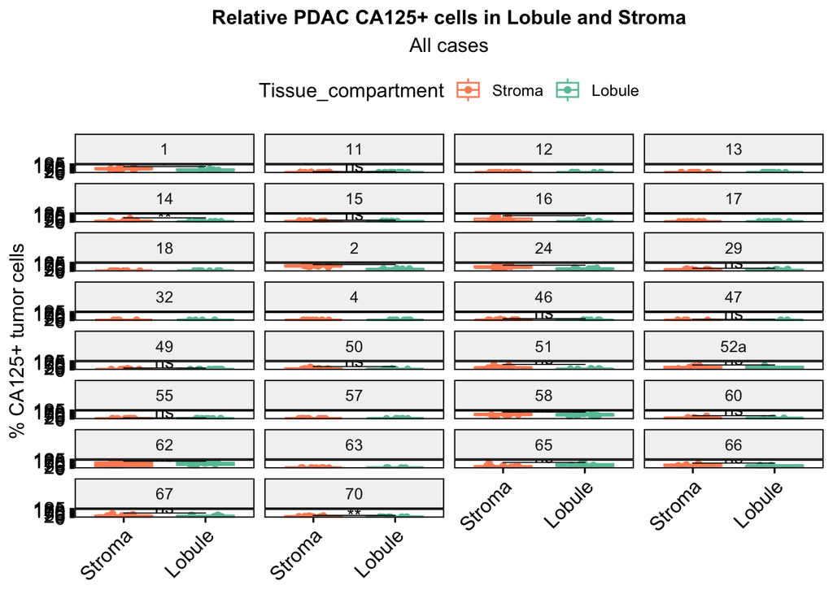

```r
boxes_ca125 <- ggboxplot(all_CA125, x = "Tissue_compartment", y = "Tumor..Positive..",
                        color = "Tissue_compartment",
                        add = "jitter",
                        facet.by = "PKR", ncol = 4, short.panel.labs = TRUE) +
  labs(title = "Relative PDAC CA125+ cells in Lobule and Stroma", subtitle = "All cases") +
  xlab(NULL) + ylab("% CA125+ tumor cells") +
  theme(plot.title = element_text(hjust = 0.5, size = 12, face = "bold"), plot.subtitle =element_text(hjust = 0.5, size = 12)) +
  theme(axis.text=element_text(size=12),
        axis.title=element_text(size=12)) +
  ylim(-1, 120) +
  theme(plot.margin = margin(0.2, 0.2, 0.2, 0.2, "cm")) +
  scale_color_manual(values = c("#FC8D62", "#66C2A5"))

stat.test_CA125_1 <- stat.test_CA125 %>% add_xy_position(x = "Tissue_compartment")

Suppl_Fig_7b <- boxes_ca125 + stat_pvalue_manual(label = "p.adj.signif",
                                stat.test_CA125_1, tip.length = 0) +
  theme(axis.text.x = element_text(angle = 45, hjust = 1))

Suppl_Fig_7b
```

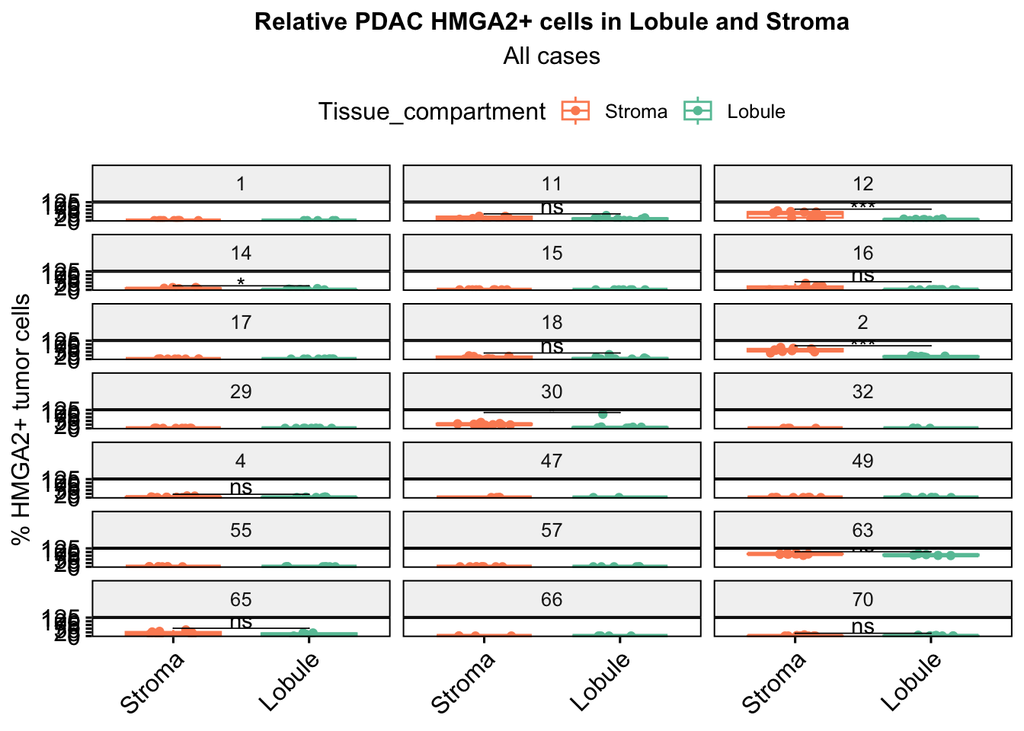

```r
boxes_HMGA2 <- ggboxplot(all_HMGA2, x = "Tissue_compartment", y = "Tumor..Positive..",
                         color = "Tissue_compartment",
                         add = "jitter",
                         facet.by = "PKR", ncol = 3, short.panel.labs = TRUE) +
  labs(title = "Relative PDAC HMGA2+ cells in Lobule and Stroma", subtitle = "All cases") +
  xlab(NULL) + ylab("% HMGA2+ tumor cells") +
  theme(plot.title = element_text(hjust = 0.5, size = 12, face = "bold"), plot.subtitle =element_text(hjust = 0.5, size = 12)) +
  theme(axis.text=element_text(size=12), axis.title=element_text(size=12)) +
  ylim(-1, 120) +
  theme(plot.margin = margin(0.2, 0.2, 0.2, 0.2, "cm"))+
  scale_color_manual(values = c("#FC8D62", "#66C2A5"))

stat.test_HMGA2_1 <- stat.test_HMGA2 %>% add_xy_position(x = "Tissue_compartment")

Suppl_Fig_6b <- boxes_HMGA2 + stat_pvalue_manual(label = "p.adj.signif",
                                 stat.test_HMGA2_1, tip.length = 0) +
  theme(axis.text.x = element_text(angle = 45, hjust = 1))

Suppl_Fig_6b
```

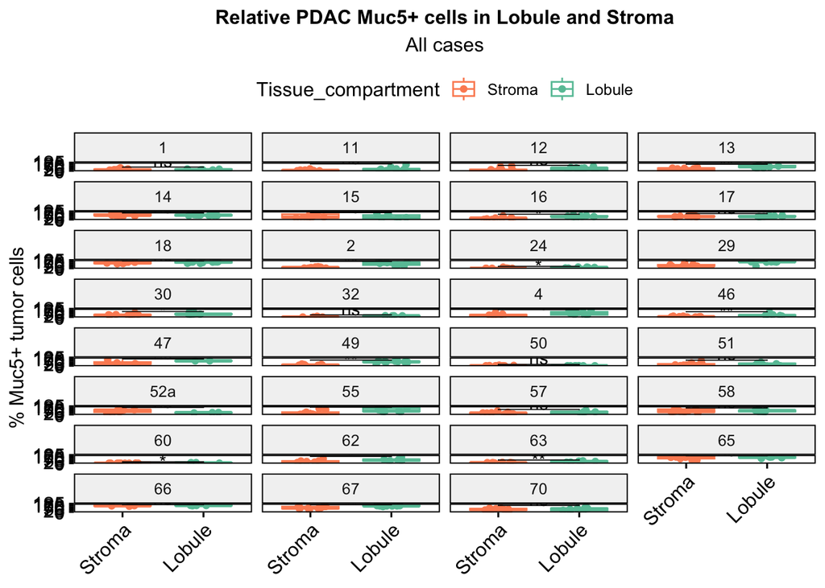

```r
boxes_Muc5 <- ggboxplot(all_Muc5, x = "Tissue_compartment", y = "Tumor..Positive..",
                       color = "Tissue_compartment",
                       add = "jitter",
                       facet.by = "PKR", ncol = 4, short.panel.labs = TRUE) +
  labs(title = "Relative PDAC Muc5+ cells in Lobule and Stroma", subtitle = "All cases") +
  xlab(NULL) + ylab("% Muc5+ tumor cells") +
  theme(plot.title = element_text(hjust = 0.5, size = 12, face = "bold"), plot.subtitle =element_text(hjust = 0.5, size = 12)) +
  theme(axis.text=element_text(size=12),
        axis.title=element_text(size=12)) +
  ylim(-1, 120) +
  theme(plot.margin = margin(0.2, 0.2, 0.2, 0.2, "cm"))+
  scale_color_manual(values = c("#FC8D62", "#66C2A5"))

stat.test_Muc5_1 <- stat.test_Muc5 %>% add_xy_position(x = "Tissue_compartment")

Suppl_Fig_8b <- boxes_Muc5 + stat_pvalue_manual(label = "p.adj.signif",
                               stat.test_Muc5_1, tip.length = 0) +
  theme(axis.text.x = element_text(angle = 45, hjust = 1))
Suppl_Fig_8b
```

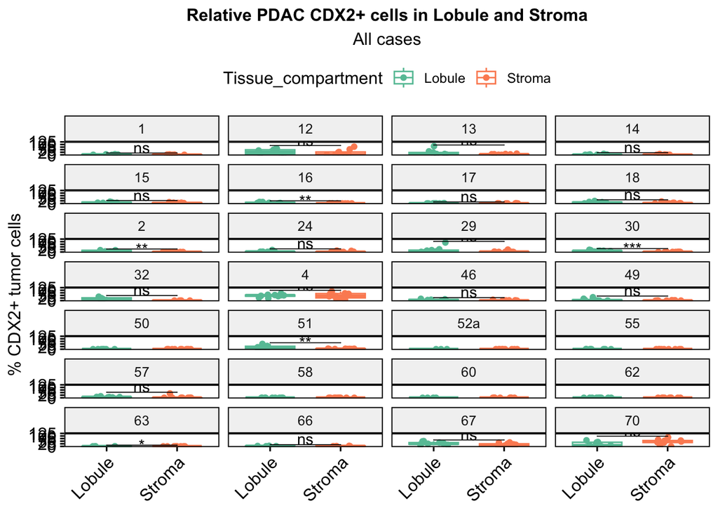

```r
boxes_CDX2 <- ggboxplot(all_CDX2, x = "Tissue_compartment", y = "Tumor..Positive..",
                        color = "Tissue_compartment", palette = "Set2",
                        add = "jitter",
                        facet.by = "PKR", ncol = 4, short.panel.labs = TRUE) +
  labs(title = "Relative PDAC CDX2+ cells in Lobule and Stroma", subtitle = "All cases") +
  xlab(NULL) + ylab("% CDX2+ tumor cells") +
  theme(plot.title = element_text(hjust = 0.5, size = 12, face = "bold"), plot.subtitle =element_text(hjust = 0.5, size = 12)) +
  theme(axis.text=element_text(size=12),
        axis.title=element_text(size=12)) +
  ylim(-1, 120) +
  theme(plot.margin = margin(0.2, 0.2, 0.2, 0.2, "cm"))

stat.test_CDX2_1 <- stat.test_CDX2 %>% add_xy_position(x = "Tissue_compartment")

Suppl_Fig_9b <- boxes_CDX2 + stat_pvalue_manual(label = "p.adj.signif",
                                stat.test_CDX2_1, tip.length = 0) +
  theme(axis.text.x = element_text(angle = 45, hjust = 1))
Suppl_Fig_9b
```

## Boxplots

Only cases significant difference between lobular - and stromal invasion.  
Each dot = 1 ROI.

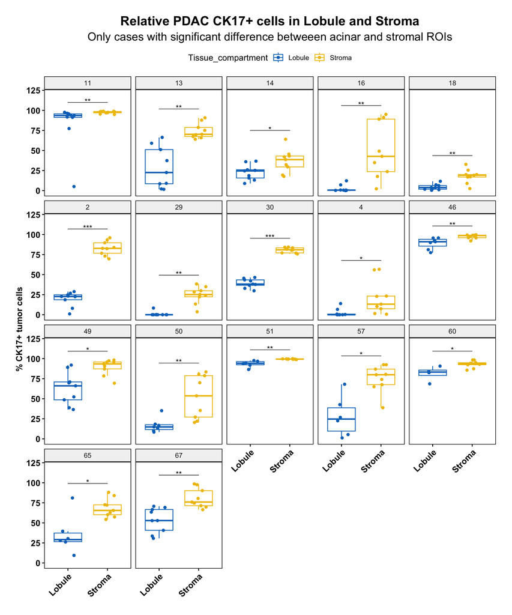

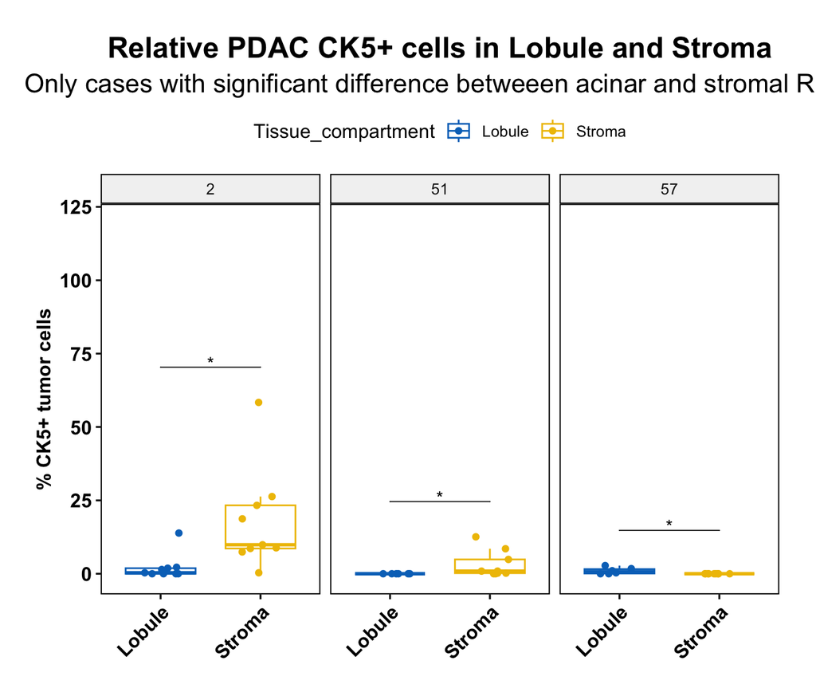

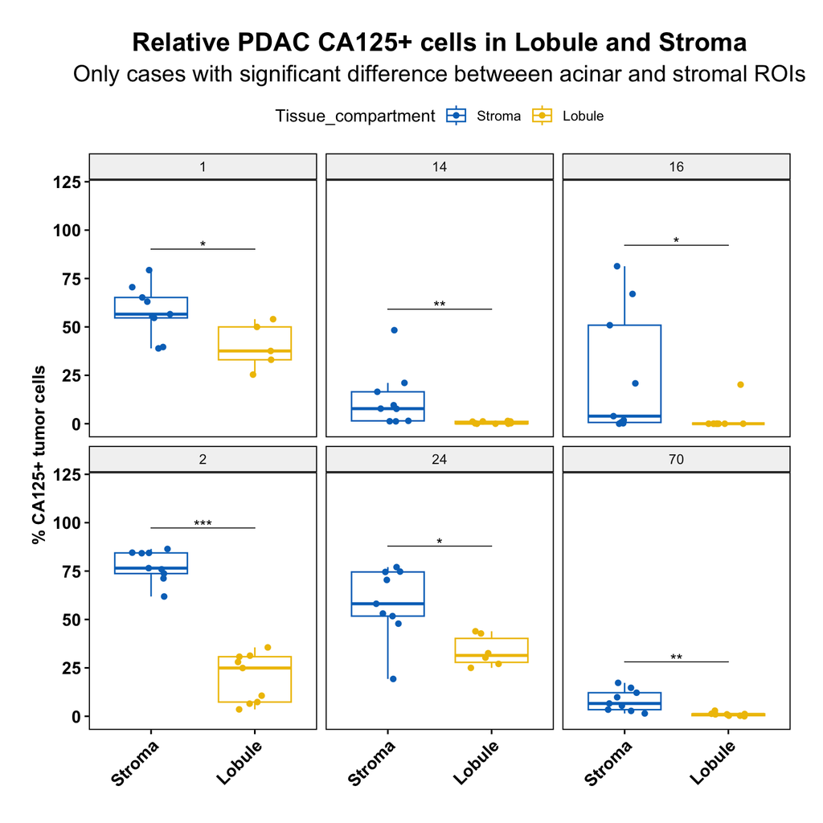

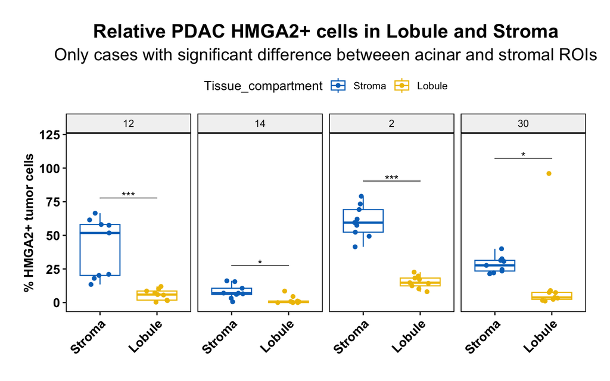

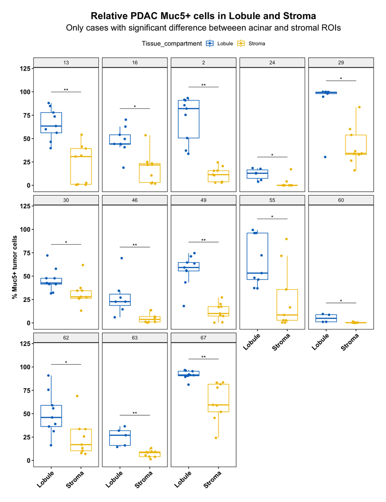

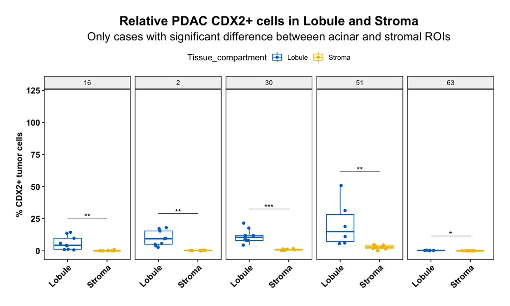

Correlation plot of the markers in IHC cohort, No imputation, enabled by using the data matrix all_combined_exl, and only using complete obervations.

```r
head(cor_A)
```

```
##            CA125       CDX2       CK17        CK5      HMGA2       Muc5
## CA125  1.0000000 -0.2810753  0.8707811  0.4855878  0.8797215 -0.5688701
## CDX2  -0.2810753  1.0000000 -0.4758926 -0.2144643 -0.2169090  0.4749056
## CK17   0.8707811 -0.4758926  1.0000000  0.5885561  0.7987999 -0.5422339
## CK5    0.4855878 -0.2144643  0.5885561  1.0000000  0.2762256 -0.4209848
## HMGA2  0.8797215 -0.2169090  0.7987999  0.2762256  1.0000000 -0.5028824
## Muc5  -0.5688701  0.4749056 -0.5422339 -0.4209848 -0.5028824  1.0000000
```

```r
head(cor_A_spear)
```

```
##            CA125       CDX2       CK17        CK5      HMGA2       Muc5
## CA125  1.0000000 -0.3084646  0.7639912  0.5154752  0.8593553 -0.3096398
## CDX2  -0.3084646  1.0000000 -0.5930051 -0.4201422 -0.2658449  0.5301835
## CK17   0.7639912 -0.5930051  1.0000000  0.4660122  0.6737171 -0.3984905
## CK5    0.5154752 -0.4201422  0.4660122  1.0000000  0.4231955 -0.6340018
## HMGA2  0.8593553 -0.2658449  0.6737171  0.4231955  1.0000000 -0.2140555
## Muc5  -0.3096398  0.5301835 -0.3984905 -0.6340018 -0.2140555  1.0000000
```

```r
head(testRes)
```

```
## $p
##              CA125         CDX2         CK17          CK5        HMGA2
## CA125 0.000000e+00 2.888282e-03 3.153729e-11 1.384304e-05 1.048558e-15
## CDX2  2.888282e-03 0.000000e+00 4.599406e-05 4.587324e-03 3.733383e-06
## CK17  3.153729e-11 4.599406e-05 0.000000e+00 1.907032e-09 2.601302e-09
## CK5   1.384304e-05 4.587324e-03 1.907032e-09 0.000000e+00 1.052497e-13
## HMGA2 1.048558e-15 3.733383e-06 2.601302e-09 1.052497e-13 0.000000e+00
## Muc5  1.673417e-01 1.340409e-03 3.937881e-16 4.357883e-04 3.447229e-09
##               Muc5
## CA125 1.673417e-01
## CDX2  1.340409e-03
## CK17  3.937881e-16
## CK5   4.357883e-04
## HMGA2 3.447229e-09
## Muc5  0.000000e+00
##
## $lowCI
##            CA125        CDX2       CK17        CK5      HMGA2        Muc5
## CA125  1.0000000 -0.33160594  0.2518562  0.1916069  0.5673797 -0.17920192
## CDX2  -0.3316059  1.00000000 -0.3120629 -0.3583226 -0.4887262  0.06676752
## CK17   0.2518562 -0.31206294  1.0000000  0.2600504  0.2898819 -0.43224971
## CK5    0.1916069 -0.35832262  0.2600504  1.0000000  0.4311637 -0.34083972
## HMGA2  0.5673797 -0.48872617  0.2898819  0.4311637  1.0000000 -0.52379566
## Muc5  -0.1792019  0.06676752 -0.4322497 -0.3408397 -0.5237957  1.00000000
##
## $uppCI
##             CA125        CDX2       CK17         CK5      HMGA2        Muc5
## CA125  1.00000000 -0.07139553  0.4381845  0.46826847  0.7753870  0.03141959
## CDX2  -0.07139553  1.00000000 -0.1131129 -0.06875649 -0.2150961  0.26928919
## CK17   0.43818452 -0.11311287  1.0000000  0.47748503  0.5263557 -0.27721735
## CK5    0.46826847 -0.06875649  0.4774850  1.00000000  0.6522895 -0.10113630
## HMGA2  0.77538701 -0.21509613  0.5263557  0.65228948  1.0000000 -0.28664106
## Muc5   0.03141959  0.26928919 -0.2772173 -0.10113630 -0.2866411  1.00000000
```

## Draw correlation matrix with complex heatmap package

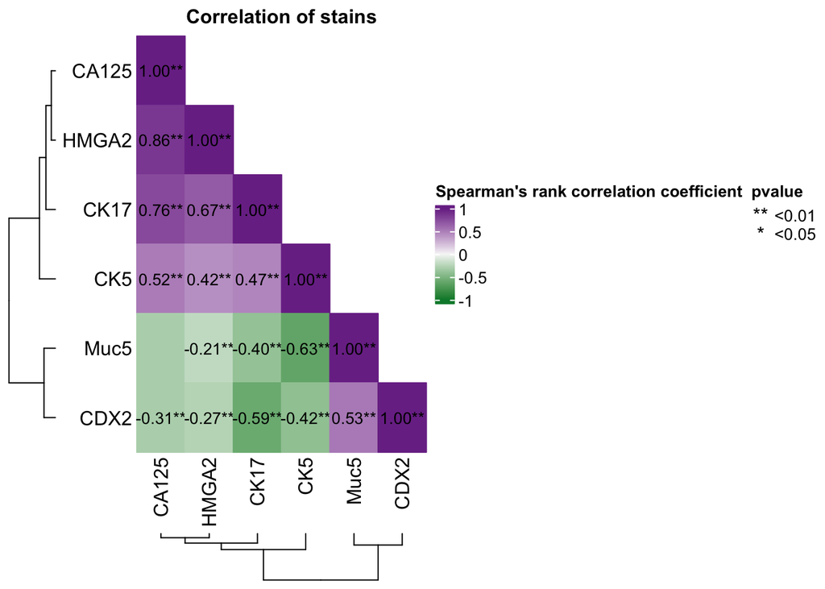

```r
cell_fun_spear = function(j, i, x, y, w, h, fill){
  if(as.numeric(x) <= 1 - as.numeric(y) + 1e-6) {
    grid.rect(x, y, w, h, gp = gpar(fill = fill, col = fill))
  }

  if (cor_p[i, j]  < 0.01 & as.numeric(x) <= 1 - as.numeric(y) + 1e-6){
    grid.text(paste0(sprintf("%.2f", cor_A_spear[i, j]),"**"), x, y, gp = gpar(fontsize = 10))
  } else if (cor_p[i, j]  <= 0.05 & as.numeric(x) <= 1 - as.numeric(y) + 1e-6){
    grid.text(paste0(sprintf("%.2f", cor_A_spear[i, j]),"*"), x, y, gp = gpar(fontsize = 10))
  }
}
hp_spear<- ComplexHeatmap::Heatmap(cor_A_spear,
                             rect_gp = gpar(type = "none"),
                             column_dend_side = "bottom",
                             column_title = "Correlation of stains",
                             column_title_gp = gpar(fontsize = 12, fontface = "bold"),
                             name = "Spearman's rank correlation coefficient", col = col_fun,
                             cell_fun = cell_fun_spear,
                             cluster_rows = T, cluster_columns = T,
                             row_names_side = "left")

lgd_list = list(
  Legend( labels = c("<0.01", "<0.05"), title = "pvalue",
          graphics = list(
            function(x, y, w, h) grid.text("**", x = x, y = y,
                                           gp = gpar(fill = "black")),
            function(x, y, w, h) grid.text("*", x = x, y = y,
                                           gp = gpar(fill = "black")))
  ))

draw(hp_spear, annotation_legend_list = lgd_list, ht_gap = unit(1, "cm") )
```

The pattern is the same with either spearman or pearson’s correlation applied, slightly different numbers.

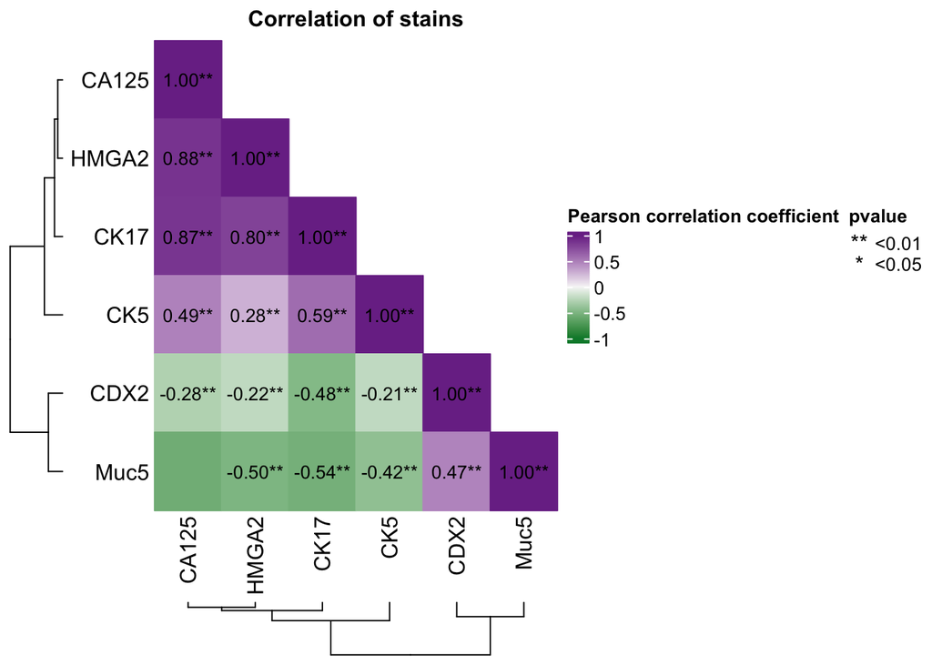

```r
Suppl_Fig_3b <- draw(hp, annotation_legend_list = lgd_list, ht_gap = unit(1, "cm") )
```

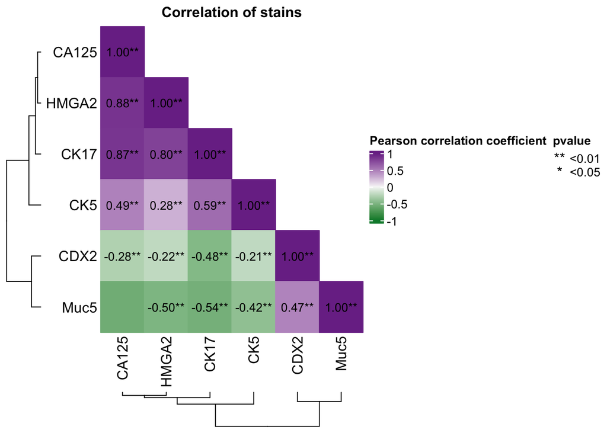

```r
Suppl_Fig_3b
```

```r
#Sanity-check:
dim(matrix_A) # 488*6 = 2928
```

```
## [1] 488   6
```

```r
#get nr of NA:
sum(is.na(matrix_A)) #823
```

```
## [1] 823
```

```r
2928-823
```

```
## [1] 2105
```

```r
nrow(all_combined_exl)
```

```
## [1] 2105
```

```r
#(dim counts) - NA = the quantified ROIs, as in the rownumbers for all_combined.

i_dim <- 2928-823
i_rows <- as.numeric(nrow(all_combined_exl))

identical(i_dim, i_rows) #2105
```

```
## [1] TRUE
```

# Heatmaps

## Heatmap type A: Case id + ROIs across Stains.

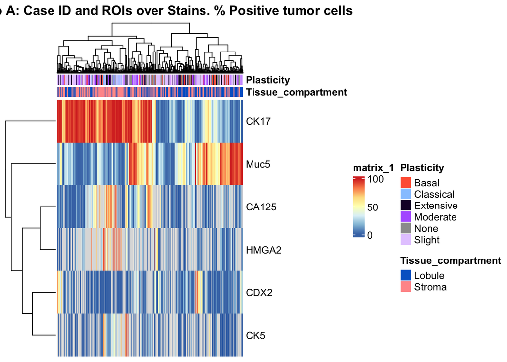

```r
pheatmap(t_m_matrix_A, fontsize_col = 6, annotation_col = m_A, annotation_colors = annot_colors_A, show_colnames = F, labels_col = "Case ID and Stain",  main = "Heatmap A: Case ID and ROIs over Stains. % Positive tumor cells", cluster_cols = T, cluster_rows = T)
```

## Heatmap type B:

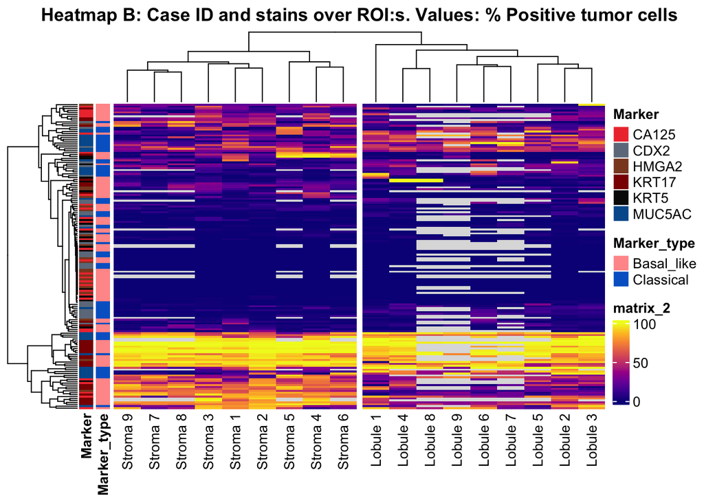

```r
Fig_2e <- pheatmap(t_m_matrix_B, cluster_rows = T, cluster_cols = T, annotation_row = m_B, color=col.pal2, annotation_colors = annot_colors_B, show_rownames = F, cutree_cols = 2, main = "Heatmap B: Case ID and stains over ROI:s. Values: % Positive tumor cells")

Fig_2e
```

```r
#Sanity-check:
dim(t_m_matrix_B) # 159*18
```

```
## [1] 159  18
```

```r
#get nr of NA:
sum(is.na(t_m_matrix_B)) #354
```

```
## [1] 354
```

```r
#(dim counts) - NA = the quantified ROIs, as in the rownumbers for all_combined.

i_dim <- (159*18)-354
i_rows <- as.numeric(nrow(all_combined))

identical(i_dim, i_rows)
```

```
## [1] TRUE
```

## Heatmap type C:

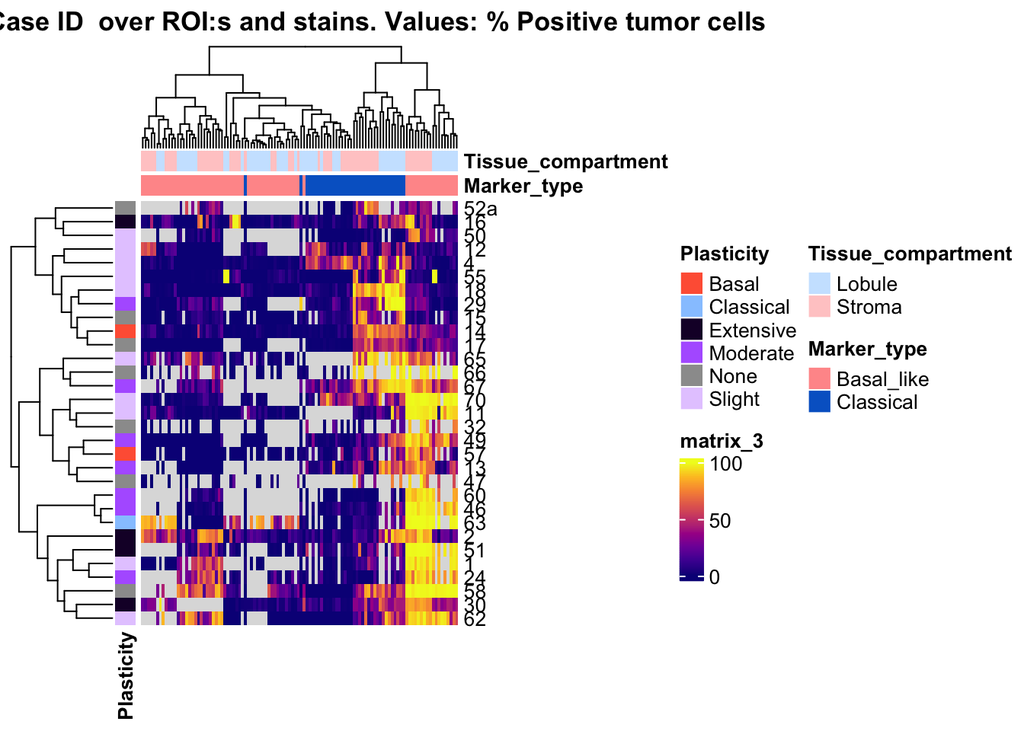

```r
pheatmap(m_matrix_C, annotation_colors = annot_colors_Call, show_colnames = F, color=col.pal2, annotation_col = m_CC, annotation_row = m_Crows, main = "Heatmap C: Case ID  over ROI:s and stains. Values: % Positive tumor cells", cluster_rows = T, cluster_cols = T)
```

## Heatmap C, averaged compartments

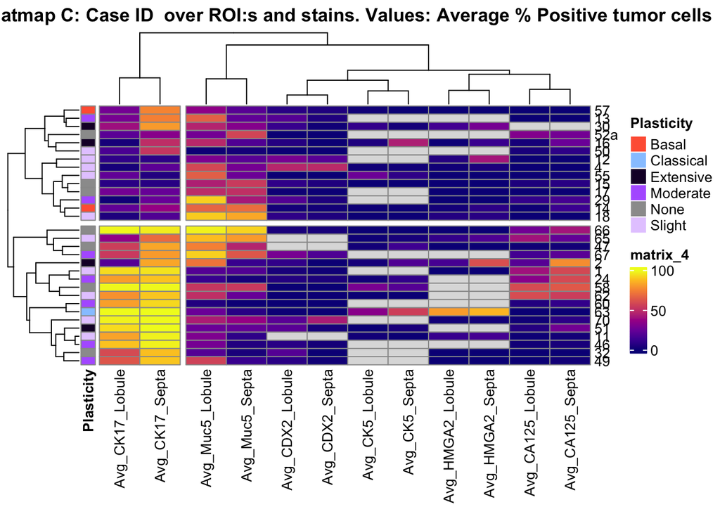

```r
pheatmap(C_AVG_2, cutree_rows = 2, annotation_colors = annot_colors_Call, color=col.pal2, annotation_row = m_Crows, cutree_cols = 2, main = "Heatmap C: Case ID  over ROI:s and stains. Values: Average % Positive tumor cells", cluster_rows = T, cluster_cols = T)
```

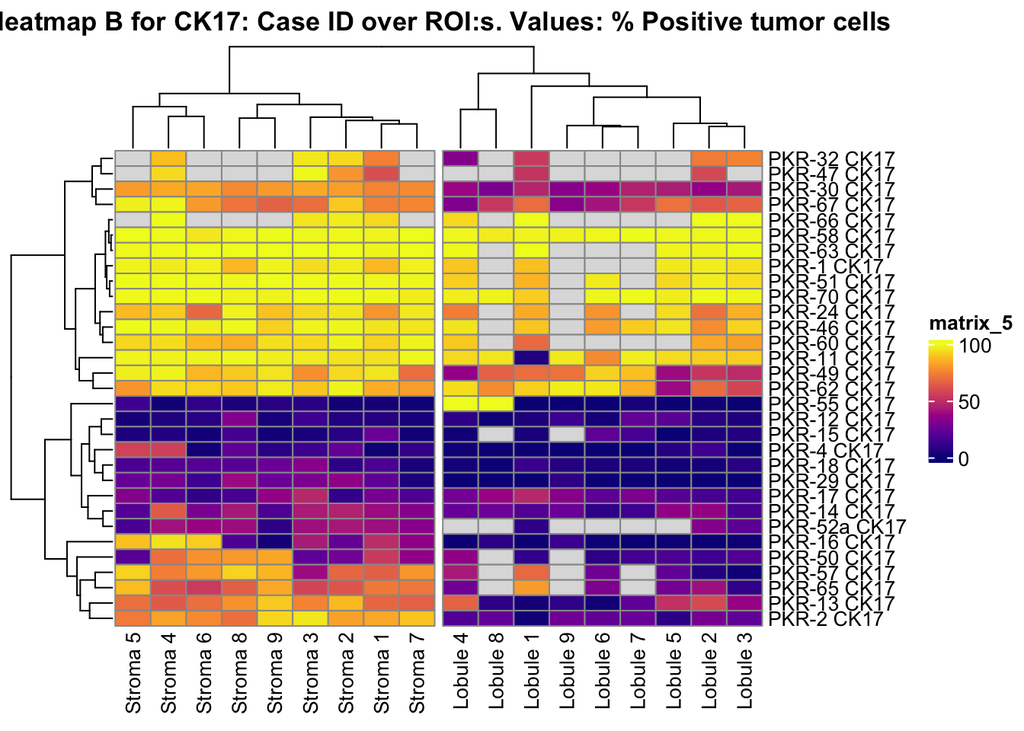

```r
pheatmap(tmB_CK17, cutree_cols = 2, color=col.pal2, main = "Heatmap B for CK17: Case ID over ROI:s. Values: % Positive tumor cells")
```

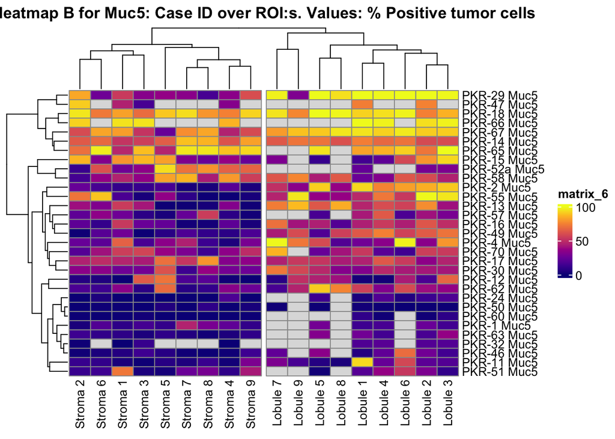

```r
pheatmap(tmB_Muc5, cutree_cols = 2,color=col.pal2, main = "Heatmap B for Muc5: Case ID over ROI:s. Values: % Positive tumor cells")
```

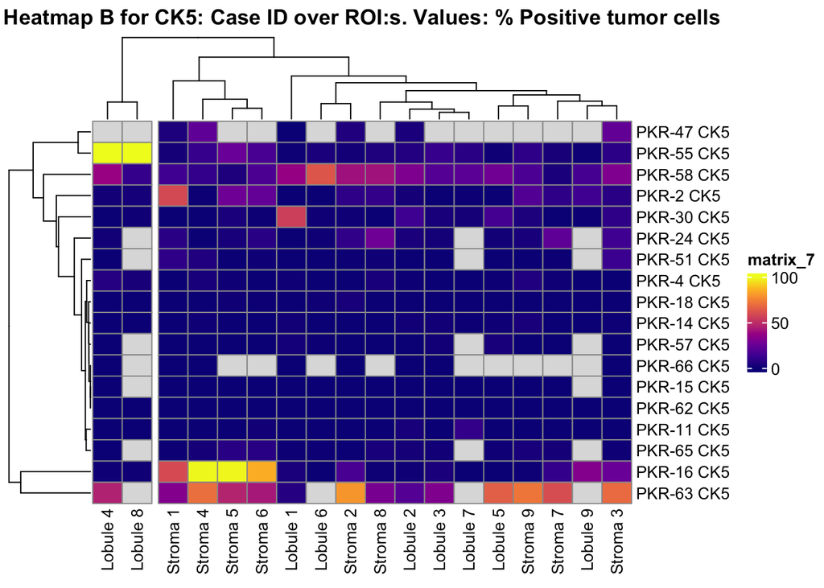

```r
pheatmap(tmB_CK5, cutree_cols = 2, color=col.pal2,main = "Heatmap B for CK5: Case ID over ROI:s. Values: % Positive tumor cells")
```

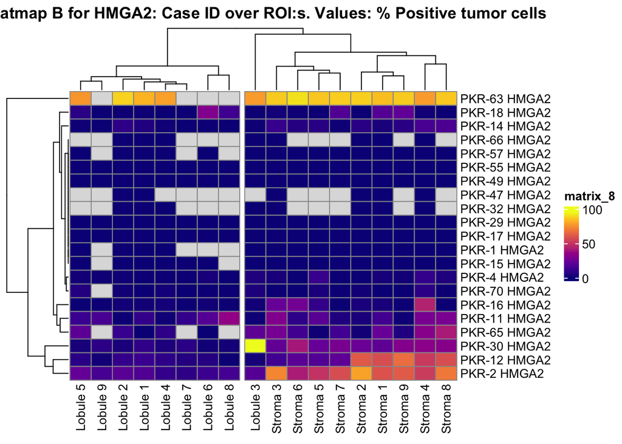

```r
pheatmap(tmB_HMGA2, cutree_cols = 2, color=col.pal2,main = "Heatmap B for HMGA2: Case ID over ROI:s. Values: % Positive tumor cells")
```

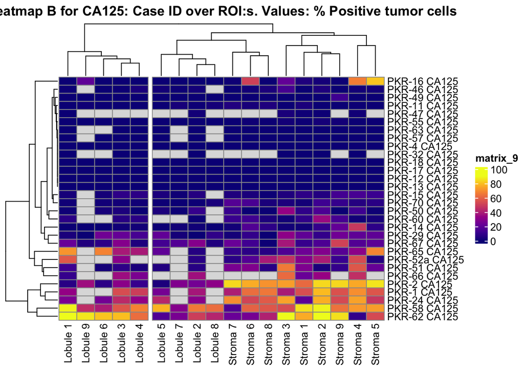

```r
pheatmap(tmB_CA125, cutree_cols = 2, color=col.pal2,main = "Heatmap B for CA125: Case ID over ROI:s. Values: % Positive tumor cells")
```

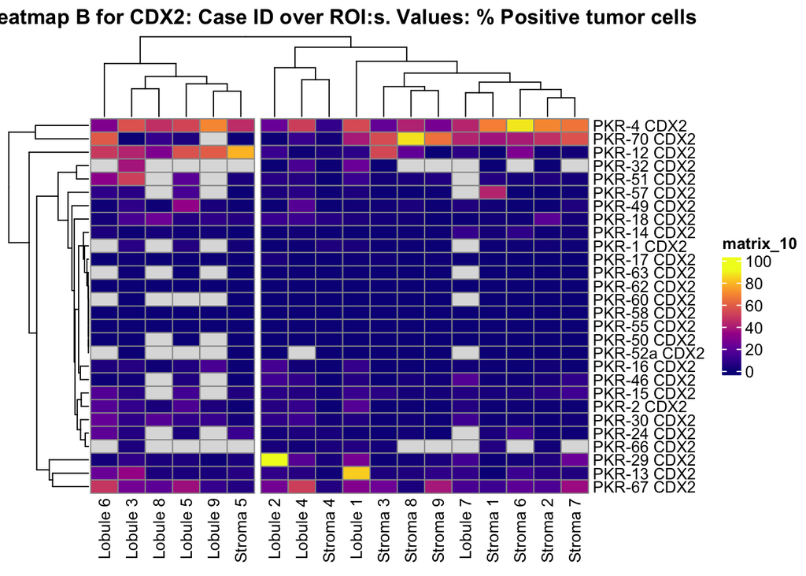

```r
pheatmap(tmB_CDX2, cutree_cols = 2,color=col.pal2, main = "Heatmap B for CDX2: Case ID over ROI:s. Values: % Positive tumor cells")
```